# Análise de Correspondências Simples

Análise de Correpondência é uma técnica não supervisionada que busca diagnosticar relação entre variáveis qualitativas, usando para tal tabelas de contigência com as frequencias das associações. Na simples temos apenas duas variáveis e chamamos de ANACOR.QUando há mais que 2 chamamos de análise de corrrespondencia multipla.

Livro Clássico: Correspondence Analysis Handbook. Autor: Benzecri

Dados do exemplo:

```r
data = read.csv("data/perfil_investidor.csv")
```

As duas variáveis serão perfil e aplicação.

Tabela de frequência observadas:

```r
tab = table(data$perfil,data$aplicacao)
print(tab)
```

```
##
##               Acoes CDB Poupanca
##   Agressivo      36  20        2
##   Conservador     5   4        8
##   Moderado        4  16        5
```

Teste qui-quadradro: associação entre as variáveis se dão de forma aleatória?

Hipotose nula: as variáveis qualitativas se associam de forma aleatória hipotese alternativa: as variáveis qualitativas Não se associam de forma aleatória

```r
teste_qui_quadrado <- chisq.test(tab)
teste_qui_quadrado
```

```
##
##  Pearson's Chi-squared test
##
## data:  tab
## X-squared = 31.764, df = 4, p-value = 2.138e-06
```

Adicionado os totais das linahs e colunas:

```r
tabela = tab
tabela = cbind(tabela, Total = rowSums(tabela))
tabela = rbind(tabela, Total = colSums(tabela))
print(tabela)
```

```
##             Acoes CDB Poupanca Total
## Agressivo      36  20        2    58
## Conservador     5   4        8    17
## Moderado        4  16        5    25
## Total          45  40       15   100
```

Tabela de frequências esperadas (probabilidades):

```r
tabela_freq_esperadas = data.frame(matrix(NA, nrow=3, ncol=3))
for (row in 1:3){
  for(col in 1:3){
    tabela_freq_esperadas[row,col] = ( tabela[row,4]*tabela[4,col] )/ tabela[4,4]
  }
}
colnames(tabela_freq_esperadas) = colnames(tab)
rownames(tabela_freq_esperadas) = rownames(tab)
tabela_freq_esperadas
```

|  | Acoes | CDB | Poupanca |
| --- | --- | --- | --- |
| Agressivo | 26.10 | 23.2 | 8.70 |
| Conservador | 7.65 | 6.8 | 2.55 |
| Moderado | 11.25 | 10.0 | 3.75 |

O teste qui-quadrado também nos fornece as frequencias esperadas:

```r
teste_qui_quadrado$expected
```

```
##
##               Acoes  CDB Poupanca
##   Agressivo   26.10 23.2     8.70
##   Conservador  7.65  6.8     2.55
##   Moderado    11.25 10.0     3.75
```

Matriz de resíduos (diferença do observado com o esperado, assim a soma dos resíduos sempre será zero):

```r
residuos =  tab-tabela_freq_esperadas
print(residuos)
```

```
##             Acoes  CDB Poupanca
## Agressivo    9.90 -3.2    -6.70
## Conservador -2.65 -2.8     5.45
## Moderado    -7.25  6.0     1.25
```

Qui-quadradro será dado pela soma dos residuos ao quadrado divido pelos valores esperados:

```r
tabela_qui_quadrado = residuos^2 / tabela_freq_esperadas
sum(tabela_qui_quadrado)
```

```
## [1] 31.76416
```

31.76416 está acima ou abaixo do valor crítico? graus de liberdade (df) da tabela de contigência = (linhas-1)*(colunas-1) = 4

5% de significância (= 95% de confiânca):

```r
qchisq(p=0.05, df =4, lower.tail=F)
```

```
## [1] 9.487729
```

9.487729 é chamado qui-quadrado crítico. Como 31.76416 é maior que 9.487729 rejeitamos a hipótese nula e ficamos com a hipótese alternativa. Podemos fazer o contrário também, encontrar o p-value para 31.76416:

```r
pchisq(q=31.76416, df =4, lower.tail=F)
```

```
## [1] 2.137599e-06
```

2.137599e-06 é bem menor que 0.05, assim rejeitamos a hipótese nula.

resíduos padrozinados:

```r
residuos_padronizados = residuos/sqrt(tabela_freq_esperadas)
residuos_padronizados
```

|  | Acoes | CDB | Poupanca |
| --- | --- | --- | --- |
| Agressivo | 1.9378267 | -0.6643638 | -2.2715127 |
| Conservador | -0.9581095 | -1.0737510 | 3.4129224 |
| Moderado | -2.1615324 | 1.8973666 | 0.6454972 |

A função qui-quadrado também nos fornece os resíduos padronizados:

```r
teste_qui_quadrado$residuals
```

```
##
##                    Acoes        CDB   Poupanca
##   Agressivo    1.9378267 -0.6643638 -2.2715127
##   Conservador -0.9581095 -1.0737510  3.4129224
##   Moderado    -2.1615324  1.8973666  0.6454972
```

Resíduos padronizados ajustados:

```r
residuos_padronizados_ajustados = data.frame(matrix(NA, nrow=3, ncol=3))
for (row in 1:3){
  for(col in 1:3){
    denominador = ( (1-tabela[row,4]/tabela[4,4]) * (1-tabela[4,col]/tabela[4,4])  )
    residuos_padronizados_ajustados[row,col] = residuos_padronizados[row,col] / sqrt(denominador)
  }
}
colnames(residuos_padronizados_ajustados) = colnames(tab)
rownames(residuos_padronizados_ajustados) = rownames(tab)
residuos_padronizados_ajustados
```

|  | Acoes | CDB | Poupanca |
| --- | --- | --- | --- |
| Agressivo | 4.031893 | -1.323444 | -3.8017282 |
| Conservador | -1.418061 | -1.521559 | 4.0632908 |
| Moderado | -3.365501 | 2.828427 | 0.8084521 |

O teste qui-quadrado também nos fornece os resíduos padronizados ajustados:

```r
teste_qui_quadrado$stdres
```

```
##
##                    Acoes        CDB   Poupanca
##   Agressivo    4.0318926 -1.3234444 -3.8017282
##   Conservador -1.4180605 -1.5215594  4.0632908
##   Moderado    -3.3655013  2.8284271  0.8084521
```

Benzecri encontrou que os resíduos padronizados ajustados em simulação com grande volume de dado regridem numa normal padrão.

Usaremos os resíduos padronizados ajustado mairoes que 1,96 (indica associação intensa entre as duas variáveis) para montar o mapa perceptual.

Viés do teste qui-quadrado: quanto maior amostra maior o teste qui-quadrado. A Inércia principal total tenta resolver isso dividindo o qui-quadrado pelo número de observações:

```r
inercia_principal_total = teste_qui_quadrado$statistic/nrow(data)
inercia_principal_total
```

```
## X-squared
## 0.3176416
```

Essa matriz A irá capturar o valor da inertia principal total, isto é, 0.3176416

P é a matriz de frequências relativas:

```r
P = 1/nrow(data) * tab
P
```

```
##
##               Acoes  CDB Poupanca
##   Agressivo    0.36 0.20     0.02
##   Conservador  0.05 0.04     0.08
##   Moderado     0.04 0.16     0.05
```

Profile é uma medida de quanto cada categoria está puxando as demais.

Column profiles (massas da linhas):

```r
column_profiles = data.frame(matrix(NA, nrow=3, ncol=3))
for (row in 1:3){
  for(col in 1:4){
    column_profiles[row,col] =  tabela[row,col]/tabela[4,col]
  }
}
colnames(column_profiles) = c(colnames(tab),'Dl')
rownames(column_profiles) = rownames(tab)
column_profiles
```

|  | Acoes | CDB | Poupanca | Dl |
| --- | --- | --- | --- | --- |
| Agressivo | 0.80000000 | 0.5 | 0.1333333 | 0.58 |
| Conservador | 0.11111111 | 0.1 | 0.5333333 | 0.17 |
| Moderado | 0.08888889 | 0.4 | 0.3333333 | 0.25 |

Row profiles (massas da colunas)

```r
row_profiles = data.frame(matrix(NA, nrow=3, ncol=3))
for (row in 1:4){
  for(col in 1:3){
    row_profiles[row,col] =  tabela[row,col]/tabela[row,4]
  }
}
colnames(row_profiles) = colnames(tab)
rownames(row_profiles) = c(rownames(tab),'Dc')
row_profiles
```

|  | Acoes | CDB | Poupanca |
| --- | --- | --- | --- |
| Agressivo | 0.6206897 | 0.3448276 | 0.03448276 |
| Conservador | 0.2941176 | 0.2352941 | 0.47058824 |
| Moderado | 0.1600000 | 0.6400000 | 0.20000000 |
| Dc | 0.4500000 | 0.4000000 | 0.15000000 |

Matriz $D_l$ é a diagonalização dos colunm profiles:

```r
Dl = diag(column_profiles$Dl)
Dl
```

```
##      [,1] [,2] [,3]
## [1,] 0.58 0.00 0.00
## [2,] 0.00 0.17 0.00
## [3,] 0.00 0.00 0.25
```

Matriz $D_c$é a diagonalização dos row profiles:

```r
Dc = diag(row_profiles[4,])
Dc
```

```
##      [,1] [,2] [,3]
## [1,] 0.45  0.0 0.00
## [2,] 0.00  0.4 0.00
## [3,] 0.00  0.0 0.15
```

Matriz lc transposta

```r
dl_matrix = as.matrix(column_profiles$Dl)
rownames(dl_matrix) = rownames(tab)
lc = dl_matrix %*% as.matrix(row_profiles[4,])
lc
```

```
##              Acoes   CDB Poupanca
## Agressivo   0.2610 0.232   0.0870
## Conservador 0.0765 0.068   0.0255
## Moderado    0.1125 0.100   0.0375
```

Matriz A

```r
A = diag(diag(Dl) ^ (-1/2)) %*% (P - lc) %*% diag(diag(Dc) ^ (-1/2))
A
```

```
##             [,1]        [,2]        [,3]
## [1,]  0.19378267 -0.06643638 -0.22715127
## [2,] -0.09581095 -0.10737510  0.34129224
## [3,] -0.21615324  0.18973666  0.06454972
```

Mas também poderíamos encontrar A assim (que é muito mais fácil):

```r
A = residuos_padronizados / sqrt(nrow(data))
A
```

|  | Acoes | CDB | Poupanca |
| --- | --- | --- | --- |
| Agressivo | 0.19378267 | -0.06643638 | -0.22715127 |
| Conservador | -0.09581095 | -0.10737510 | 0.34129224 |
| Moderado | -0.21615324 | 0.18973666 | 0.06454972 |

Matriz W:

```r
W <- t(A) %*% as.matrix(A)
W
```

```
##                Acoes         CDB    Poupanca
## Acoes     0.09345368 -0.04359870 -0.09067015
## CDB      -0.04359870  0.05194320 -0.00930773
## Poupanca -0.09067015 -0.00930773  0.17224476
```

Extraindo os autovalores da matriz W:

```r
autovalores <- eigen(W)
autovalores$values
```

```
## [1] 2.332149e-01 8.442678e-02 5.551115e-17
```

A soma do autovalores nos da o valor da inércia principal total explicada.

O primeiro auto valor explica 73,4% da inércia principal total:

```r
autovalores$values[1]/sum(autovalores$values)
```

```
## [1] 0.7342075
```

inercia principal total explicada:

```r
inercia_principal_total_explicada <- autovalores$values[1:2] / inercia_principal_total
inercia_principal_total_explicada
```

```
## [1] 0.7342075 0.2657925
```

Para encontrarmos as coordenadas do mapa perceptual temos que fazer a decomposição do valor singular da Matriz A:

```r
dimensao = min(nrow(tab),ncol(tab))
decomposicao <- svd(x = A, nu = dimensao,nv = dimensao)
decomposicao
```

```
## $d
## [1] 4.829233e-01 2.905629e-01 1.116183e-17
##
## $u
##            [,1]       [,2]      [,3]
## [1,] -0.6249119 -0.1717122 0.7615773
## [2,]  0.6716248 -0.6155649 0.4123106
## [3,]  0.3980015  0.7691520 0.5000000
##
## $v
##             [,1]       [,2]      [,3]
## [1,] -0.56215025 -0.4837221 0.6708204
## [2,]  0.09300977  0.7689923 0.6324555
## [3,]  0.82178847 -0.4179279 0.3872983
```

Raiz quadrada dos autovalores:

```r
decomposicao$d
```

```
## [1] 4.829233e-01 2.905629e-01 1.116183e-17
```

Raiz quadrada dos autovalores:

```r
decomposicao$d
```

```
## [1] 4.829233e-01 2.905629e-01 1.116183e-17
```

```r
sqrt(autovalores$values)
```

```
## [1] 4.829233e-01 2.905629e-01 7.450581e-09
```

Vetor u:

```r
Am = as.matrix(A)
eigen(Am %*% t(Am))
```

```
## eigen() decomposition
## $values
## [1]  2.332149e-01  8.442678e-02 -5.551115e-17
##
## $vectors
##            [,1]       [,2]      [,3]
## [1,]  0.6249119 -0.1717122 0.7615773
## [2,] -0.6716248 -0.6155649 0.4123106
## [3,] -0.3980015  0.7691520 0.5000000
```

```r
decomposicao$u
```

```
##            [,1]       [,2]      [,3]
## [1,] -0.6249119 -0.1717122 0.7615773
## [2,]  0.6716248 -0.6155649 0.4123106
## [3,]  0.3980015  0.7691520 0.5000000
```

Vetor v:

```r
eigen(t(Am) %*% Am)
```

```
## eigen() decomposition
## $values
## [1] 2.332149e-01 8.442678e-02 5.551115e-17
##
## $vectors
##             [,1]       [,2]       [,3]
## [1,]  0.56215025  0.4837221 -0.6708204
## [2,] -0.09300977 -0.7689923 -0.6324555
## [3,] -0.82178847  0.4179279 -0.3872983
```

```r
decomposicao$v
```

```
##             [,1]       [,2]      [,3]
## [1,] -0.56215025 -0.4837221 0.6708204
## [2,]  0.09300977  0.7689923 0.6324555
## [3,]  0.82178847 -0.4179279 0.3872983
```

X e Y para perfil:

```r
Xl_perfil <- diag((decomposicao$d[1]) * diag(diag(Dl)^(-1/2)) * decomposicao$u[,1])
Xl_perfil
```

```
## [1] -0.3962625  0.7866479  0.3844084
```

```r
#Variável em linha - coordenada no eixo das ordenadas
Yl_perfil <- diag((decomposicao$d[2]) * diag(diag(Dl)^(-1/2)) * decomposicao$u[,2])
Yl_perfil
```

```
## [1] -0.06551296 -0.43379993  0.44697402
```

X e Y para aplicação:

```r
Xc_aplicacao <- diag((decomposicao$d[1]) * diag(diag(Dc)^(-1/2)) * decomposicao$v[,1])
Xc_aplicacao
```

```
## [1] -0.40469167  0.07101935  1.02469008
```

```r
Yc_aplicacao <- diag((decomposicao$d[2]) * diag(diag(Dc)^(-1/2)) * decomposicao$v[,2])
Yc_aplicacao
```

```
## [1] -0.2095221  0.3532906 -0.3135421
```

Guardando as coordenadas de cada categoria e de cada variável em um dataframe:

```r
data$perfil = as.factor(data$perfil)
data$aplicacao = as.factor(data$aplicacao)
coordenadas <- data.frame(Categorias = cbind(c(levels(data$perfil), levels(data$aplicacao))),
                          Dim1 = cbind(c(Xl_perfil, Xc_aplicacao)),
                          Dim2 = cbind(c(Yl_perfil, Yc_aplicacao)))
coordenadas
```

| Categorias | Dim1 | Dim2 |
| --- | --- | --- |
| Agressivo | -0.39626247 | -0.06551296 |
| Conservador | 0.78664791 | -0.43379993 |
| Moderado | 0.38440835 | 0.44697402 |
| Acoes | -0.40469167 | -0.20952208 |
| CDB | 0.07101935 | 0.35329062 |
| Poupanca | 1.02469008 | -0.31354207 |

Adicionando a coluna com o tipo da categoria:

```r
library(tibble)
library(tidyverse)

variaveis <- apply(data[,2:3],
                   MARGIN =  2,
                   FUN = function(x) nlevels(as.factor(x)))

matrix_mapa_perceptual <- data.frame(coordenadas,Variaveis = rep(names(variaveis), variaveis))

matrix_mapa_perceptual = rename(matrix_mapa_perceptual,Category = 1)

matrix_mapa_perceptual = rownames_to_column(matrix_mapa_perceptual)
matrix_mapa_perceptual
```

| rowname | Category | Dim1 | Dim2 | Variaveis |
| --- | --- | --- | --- | --- |
| 1 | Agressivo | -0.39626247 | -0.06551296 | perfil |
| 2 | Conservador | 0.78664791 | -0.43379993 | perfil |
| 3 | Moderado | 0.38440835 | 0.44697402 | perfil |
| 4 | Acoes | -0.40469167 | -0.20952208 | aplicacao |
| 5 | CDB | 0.07101935 | 0.35329062 | aplicacao |
| 6 | Poupanca | 1.02469008 | -0.31354207 | aplicacao |

Mapa perceptual bidimensional:

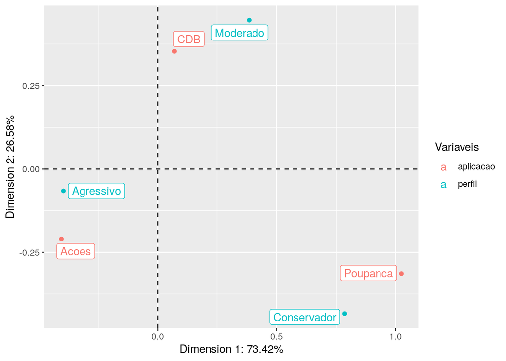

```r
library(ggplot2)
library(ggrepel)

lab_x = paste("Dimension 1:", paste0(round(inercia_principal_total_explicada[1] * 100, digits = 2), "%"))
lab_y = paste("Dimension 2:", paste0(round(inercia_principal_total_explicada[2] * 100, digits = 2), "%"))

ggplot(data = matrix_mapa_perceptual,
       aes(x = Dim1, y = Dim2, label = Category, color = Variaveis)) +
  geom_point() +
  geom_label_repel() +
  geom_hline(yintercept = 0, linetype = "dashed") +
  geom_vline(xintercept = 0, linetype = "dashed") +
  labs(x = lab_x, y = lab_y)
```